# Diabetes BMI Indicator Prediction

Author

Alejandro Gutierrez, Barry Siu, Michael Chan, Migs Dimayacyac

Published

November 21, 2026

# Imports

```python
import pandas as pd
import altair as alt
from pathlib import Path
from ucimlrepo import fetch_ucirepo
from sklearn.model_selection import train_test_split, GridSearchCV
from sklearn.preprocessing import StandardScaler
from sklearn.linear_model import LogisticRegression
from sklearn.dummy import DummyClassifier
from sklearn.pipeline import make_pipeline
from sklearn.metrics import accuracy_score, precision_score, recall_score, f1_score, roc_auc_score

# increase dataset rows limit, default 5000
alt.data_transformers.enable("vegafusion")
```

```
DataTransformerRegistry.enable('vegafusion')
```

# Summary

In this project, we investigated whether body mass index (BMI) can be used to predict diabetes status. We used the Centers for Disease Control and Prevention (CDC) Diabetes Health Indicators data set, which contains 253,680 survey responses from U.S. adults collected through the 2015 Behavioral Risk Factor Surveillance System (BRFSS), where the target indicates whether a respondent has diabetes or prediabetes. We trained a logistic regression model with BMI as the only predictor and compared it with a dummy classifier that always predicts “no diabetes”. Because only a small proportion of respondents have diabetes, we used cross-validation to select a class-balanced model and evaluated performance mainly with the F1 score rather than accuracy. Exploratory analysis showed that respondents with diabetes tend to have higher BMI values. Our model correctly identified more than half of the diabetes cases in the test set, whereas the baseline identified none. However, our model had lower overall accuracy than the baseline because it produced a large number of false positives, and it still missed many true cases. These results suggest that BMI is a useful but limited predictor of diabetes on its own, and that a BMI-only model is not suitable for screening or diagnosis. Adding other known risk factors and validating the model on Canadian data would be needed before such a model could support Canadian public health efforts.

# Introduction

Diabetes mellitus (commonly referred to as diabetes) is a metabolic disorder in which there is a lack of insulin secretion, the development of insulin resistance, or a combination of both. Without enough insulin, or without a normal response to it, the body cannot regulate blood glucose levels properly, leading to a condition known as hyperglycemia. Short-term symptoms of hyperglycemia include dehydration, fatigue or weakness, and blurred vision. Hyperglycemia is also dangerous long term, as its effects include kidney damage, heart disease, and poor wound healing, which leads to a much higher risk of infection. Diabetes can be classified as type 1 or type 2. Type 1 diabetes results from little or no insulin production, whereas type 2 diabetes results from the body becoming resistant to insulin, so that the pancreas cannot produce enough insulin to compensate. Depending on the type of diabetes, a patient may require prescribed insulin and regular blood glucose monitoring (Antar et al. 2023).

Diabetes has a large impact on the health of Canadians. In 2023–2024, the Public Health Agency of Canada found that 3.9 million Canadians live with diagnosed diabetes (Public Health Agency of Canada 2025). Diabetes is the seventh leading cause of death in Canada, with 6,874 diabetes-related deaths in 2024 alone (Statistics Canada n.d.b). Diabetes also places a significant financial burden on Canada: in 2024, it cost the Canadian health care system $18.25 billion (Diabetes Canada n.d.).

From a public health perspective, it is important to understand the impact of diabetes on Canadians, as this can support more equitable allocation of health resources and better preventive education. Statistics Canada reports that diabetes is more common in Newfoundland and Labrador (11.1%) and Nova Scotia (10.5%) than in British Columbia (6.8%), and much more common among Canadians with a disability (16.6%) than among those without (6.9%) (Statistics Canada n.d.a). Overweight and obesity are both risk factors for diabetes (Statistics Canada n.d.a), and BMI is one method of classifying body weight in relation to health risk. Understanding how risk factors affect diabetes prevalence can help educate the public on developing healthy habits that reduce the risk of diabetes. Understanding regional variations in diabetes prevalence and their effects on Canadians is also important for providing equitable health care and informing public health decisions.

Our analysis investigates how well BMI predicts diabetes status in U.S. adults, with relevance to Canadian public health. Previous research has found that, when BMI values are correctly reported, they provide a good measure of obesity prevalence (Connor Gorber et al. 2008). If BMI can predict diabetes status, this would support obesity as a key risk factor and BMI as a measure of that risk. Our model provides insight into the risks associated with diabetes and a better understanding of the strength of those risks. A model describing the association between BMI and diabetes status can help inform health decisions and policy regarding diabetes.

# Methods

## Data

The data set used in this project is the CDC Diabetes Health Indicators data set, which contains health care statistics and lifestyle survey responses from U.S. adults along with their diabetes status. The data were originally collected by the CDC through the BRFSS, an annual health-related telephone survey (Centers for Disease Control and Prevention 2015). The version we use is a cleaned subset of the 2015 BRFSS survey prepared by Alex Teboul (Teboul 2021). It was sourced from the University of California, Irvine (UCI) Machine Learning Repository (“CDC Diabetes Health Indicators” 2017) and can be found [here](https://archive.ics.uci.edu/dataset/891/cdc+diabetes+health+indicators).

Each row in the data set represents one survey respondent, giving 253,680 rows and 21 features with no missing values. The target variable, diabetes status, indicates whether the respondent has no diabetes (0) or has prediabetes or diabetes (1). The features include chronic health conditions (e.g., high blood pressure, high cholesterol, heart disease), lifestyle factors (e.g., BMI, smoking, physical activity, fruit and vegetable consumption), health care access, self-rated physical and mental health, and demographic information (sex, age group, education, and income).

(Note: Claude AI helped generate this description of how the data were curated and made publicly available)

We download the data with the code below. The data are retrieved from the “CDC Diabetes Health Indicators” entry in the UCI Machine Learning Repository (ID 891) using the ucimlrepo Python package, which returns the features and the target variable as separate data frames. We combine them into a single data set and save it as `cdc_diabetes_health_indicators.csv` in `data/raw/`, so the analysis can be re-run from the saved file without downloading the data again.

```python
# path to the saved raw data
raw_path = Path("../data/raw/cdc_diabetes_health_indicators.csv")

# only download the data if it has not been saved yet
if not raw_path.exists():
    cdc_diabetes_health_indicators = fetch_ucirepo(id=891)

    # combine the features and target into one data frame
    df = pd.concat(
        [cdc_diabetes_health_indicators.data.features,
         cdc_diabetes_health_indicators.data.targets],
        axis=1
    )

    # save raw dataset into data/raw
    raw_path.parent.mkdir(parents=True, exist_ok=True)
    df.to_csv(raw_path, index=False)

# read the data from the saved file
df = pd.read_csv(raw_path)
```

## Splitting our data into training and test sets

To predict diabetes status, we first split the data into a training set (80%) and a test set (20%). Because most respondents do not have diabetes, we used a stratified split so that both sets have the same proportion of diabetic and non-diabetic respondents. The training and test sets were saved to `data/processed/`, and the test set was set aside until the final evaluation so that it would not influence model building.

We selected BMI as our only predictor and diabetes status as our target variable because our research question focuses on whether BMI alone can predict diabetes. Keeping only these two variables lets us evaluate the predictive ability of BMI on its own. Additionally, splitting the data at this stage avoids using information from the test set to make modelling decisions.

```python
# select the target and prediction feature
df = df[["BMI", "Diabetes_binary"]]

# split data in train and test, stratify is to ensure there are enough examples in both splits
# because most examples are non diabetic
# the split is done before exploring the data so the test set is not used in the BMI plot
train_df, test_df = train_test_split(
    df,
    test_size=0.2,
    random_state=522,
    stratify=df["Diabetes_binary"]
)

# Create processed data directory
processed_dir = Path("../data/processed")
processed_dir.mkdir(parents=True, exist_ok=True)

# save the files and check the df shapes
train_df.to_csv(processed_dir / "train.csv", index=False)
test_df.to_csv(processed_dir / "test.csv", index=False)

print("Training set (rows, columns):", train_df.shape)
print("Test set (rows, columns):", test_df.shape)
```

```
Training set (rows, columns): (202944, 2)
Test set (rows, columns): (50736, 2)
```

## Applicability of U.S. data to the Canadian context

Although the data set describes U.S. adults, we chose it because it is large, publicly available, and contains individual-level information on many well-established diabetes risk factors, which makes it well suited to building a classification model. These findings are also relevant to Canadian public health. Canada and the United States share similar risk factors for type 2 diabetes: many of the variables in our data set, including age, BMI, physical activity, fruit and vegetable consumption, and high blood pressure, are the same factors used in the Canadian Diabetes Risk Questionnaire (CANRISK) developed by the Public Health Agency of Canada (Robinson, Agarwal, and Nerenberg 2011). Diabetes is also a major public health concern in Canada, where 9.4% of people were living with diagnosed diabetes in 2020–2021 (Public Health Agency of Canada 2023). The two countries differ mainly in how common these risk factors are rather than in which factors matter, with Americans more likely than Canadians to report diabetes and high blood pressure (Lasser, Himmelstein, and Woolhandler 2006). As a result, the relationships our model learns are likely to apply in a Canadian setting, although the model would need to be validated on Canadian data, such as the Canadian Community Health Survey, before being used in practice.

(Note: Claude AI helped generate this rationale for applying this data set in a Canadian context)

## Body mass index as a predictor of diabetes

High BMI is strongly associated with diabetes (Rafiq and Jeppesen 2018). Based on this, we first compared the distribution of BMI between respondents with diabetes or prediabetes and those without (Figure 1).

```python
# use only the training data so the test set stays unseen
# .copy() so adding a new column does not change train_df
plot_df = train_df[["BMI", "Diabetes_binary"]].copy()

# The following plot was made using GPT6 for assistance.
plot_df["Diabetes status"] = plot_df["Diabetes_binary"].map({
    0: "No diabetes",
    1: "Diabetes or prediabetes"
})

# Compare BMI distributions
bmi_plot = alt.Chart(plot_df, width=600, height=300).transform_density(
    "BMI",
    groupby=["Diabetes status"]
).mark_area(opacity=0.6).encode(
    x=alt.X("value:Q", title="Body Mass Index (BMI)"),
    y=alt.Y("density:Q", stack=False, title="Density"),
    color=alt.Color("Diabetes status:N")
).properties(
    title="BMI Distribution by Diabetes Status"
)

# save the plot as a png (uses vl-convert) so it renders the same in any output format
figures_dir = Path("../results/figures")
figures_dir.mkdir(parents=True, exist_ok=True)
bmi_plot.save(figures_dir / "bmi_distribution.png", scale_factor=2)
```

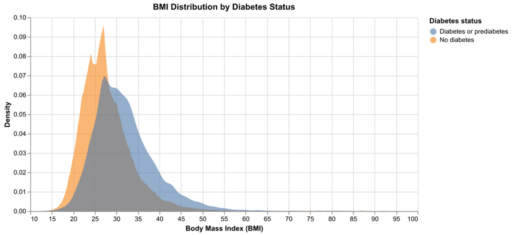

Figure 1: BMI distribution by diabetes status in the training data.

```python
from IPython.display import Image

Image(filename=figures_dir / "bmi_distribution.png", width=650)
```

Figure 1 shows that the BMI distribution for respondents with diabetes or prediabetes is shifted toward higher values compared with those without diabetes, and Table 1 shows that their mean and median BMI are also higher. This supports our choice of BMI as a predictor of diabetes status.

```python
# BMI summary by diabetes status using training data
bmi_summary = (
    train_df.groupby("Diabetes_binary")["BMI"]
    .agg(["count", "mean", "median", "std"])
    .rename(
        index={0: "No diabetes", 1: "Diabetes or prediabetes"},
        columns={"count": "Count", "mean": "Mean", "median": "Median", "std": "Standard deviation"}
    )
    .round(2)
)
bmi_summary.index.name = "Diabetes status"
bmi_summary
```

Table 1: Summary statistics of BMI by diabetes status in the training data.

| Diabetes status | Count | Mean | Median | Standard deviation |
| --- | --- | --- | --- | --- |
| No diabetes | 174667 | 27.81 | 27.0 | 6.29 |
| Diabetes or prediabetes | 28277 | 31.89 | 31.0 | 7.27 |

## Applying BMI to predict diabetes status

We then built a logistic regression model in a pipeline that first standardizes BMI, rescaling it to have a mean of 0 and a standard deviation of 1. To address the class imbalance, we used grid search with 3-fold cross-validation to compare a standard logistic regression with a class-balanced version, which gives more weight to the smaller diabetic class during training. We used the F1 score as the evaluation metric because it balances precision and recall. Accuracy would be misleading here, since a model that predicts “no diabetes” for everyone would still score highly.

```python
# select BMI as the prediction feature and diabetes as the target
X_train = train_df[["BMI"]]
y_train = train_df["Diabetes_binary"]

X_test = test_df[["BMI"]]
y_test = test_df["Diabetes_binary"]

# create the logistic regression model
logistic_model = make_pipeline(
    StandardScaler(),
    LogisticRegression(max_iter=1000)
)
```

```python
# compare regular and balanced logistic regression
param_grid_logistic = {
    "logisticregression__class_weight": [None, "balanced"]
}

# use F1 score to balance precision and recall
logistic_search = GridSearchCV(
    estimator=logistic_model,
    param_grid=param_grid_logistic,
    cv=3,
    scoring="f1",
    n_jobs=-1
)

# train the model (semicolon hides the model printout)
logistic_search.fit(X_train, y_train);

# report the selected class weighting and cross-validation F1 score in plain language
best_weight = logistic_search.best_params_["logisticregression__class_weight"]
print("Selected model:", "class-balanced" if best_weight == "balanced" else "standard (unweighted)")
print("Mean cross-validation F1 score:", round(logistic_search.best_score_, 4))
```

```
Selected model: class-balanced
Mean cross-validation F1 score: 0.3332
```

# Analysis and Results

Our logistic regression model uses BMI to estimate the probability that a respondent has diabetes. If the predicted probability is 50% or higher, the model classifies the respondent as having diabetes; otherwise, it classifies the respondent as not having diabetes.

## Baseline comparison with a dummy classifier

To judge whether our logistic regression model is actually learning from BMI, we compared it with a dummy classifier that ignores BMI entirely and always predicts the most common class, “no diabetes”. Because most respondents in our data set do not have diabetes, this baseline achieves a high accuracy without identifying a single diabetes case, giving it a recall and F1 score of zero. Comparing the two models shows how much predictive value BMI adds beyond simply guessing the majority class, and it highlights why accuracy alone is a misleading measure of performance for imbalanced data such as ours.

```python
# baseline model: always predicts the most common class (no diabetes)
# used to check that our model does better than simply guessing
dummy_model = DummyClassifier(strategy="most_frequent")
dummy_model.fit(X_train, y_train)
```

## Predicting diabetes status on the test set

```python
# predict diabetes using the test data
logistic_pred = logistic_search.predict(X_test)
dummy_pred = dummy_model.predict(X_test)
```

## Evaluating model performance

We evaluated both models on the test set using accuracy, precision, recall, F1 score, and the area under the receiver operating characteristic curve (ROC AUC), which measures how well a model ranks respondents with diabetes above those without, regardless of the classification threshold.

```python
# calculate accuracy, precision, recall, F1 score and ROC AUC for both models
def get_scores(y_true, y_pred, y_prob):
    return {
        "Accuracy": accuracy_score(y_true, y_pred),
        "Precision": precision_score(y_true, y_pred, zero_division=0),
        "Recall": recall_score(y_true, y_pred, zero_division=0),
        "F1 score": f1_score(y_true, y_pred, zero_division=0),
        "ROC AUC": roc_auc_score(y_true, y_prob)
    }

# predicted probabilities for diabetes
logistic_prob = logistic_search.predict_proba(X_test)[:,1]
dummy_prob = dummy_model.predict_proba(X_test)[:,1]

# save results on the test set
score_results = pd.DataFrame(
    [get_scores(y_test, dummy_pred, dummy_prob), get_scores(y_test, logistic_pred, logistic_prob)],
    index=["Dummy classifier (baseline)", "Logistic regression"]
)
```

```python
# compare the predicted and actual diabetes status
confusion_matrix = pd.crosstab(
    y_test,
    logistic_pred,
    rownames=["Actual diabetes status"],
    colnames=["Predicted diabetes status"]
)
```

### Test set scores

```python
# accuracy, precision, recall, F1 score and ROC AUC in a df
score_results.round(3)
```

Table 2: Test set performance of the dummy classifier and the logistic regression model.

|  | Accuracy | Precision | Recall | F1 score | ROC AUC |
| --- | --- | --- | --- | --- | --- |
| Dummy classifier (baseline) | 0.861 | 0.000 | 0.000 | 0.000 | 0.500 |
| Logistic regression | 0.676 | 0.235 | 0.588 | 0.336 | 0.692 |

### Confusion matrix

```python
# confusion matrix with plain-language labels for display
# (the numeric version is kept for the calculations below)
status_labels = {0: "No diabetes", 1: "Diabetes or prediabetes"}
confusion_matrix.rename(index=status_labels, columns=status_labels)
```

Table 3: Confusion matrix of the logistic regression model on the test set.

| Predicted diabetes status Actual diabetes status | No diabetes | Diabetes or prediabetes |
| --- | --- | --- |
| No diabetes | 30153 | 13514 |
| Diabetes or prediabetes | 2913 | 4156 |

## Interpreting the results

```python
# values reported in the text below, so the numbers update automatically
# Markdown() keeps the formatting (e.g. trailing zeros) when shown inline
from IPython.display import Markdown

logistic_scores = score_results.loc["Logistic regression"]

accuracy_text = Markdown(f"{logistic_scores['Accuracy']:.2%}")
f1_text = Markdown(f"{logistic_scores['F1 score']:.4f}")
recall_text = Markdown(f"{logistic_scores['Recall']:.2%}")
auc_text = Markdown(f"{logistic_scores['ROC AUC']:.4f}")

true_positives = int(confusion_matrix.loc[1, 1])
false_negatives = int(confusion_matrix.loc[1, 0])
false_positives = int(confusion_matrix.loc[0, 1])
```

As shown in Table 2, the logistic regression model has an accuracy of 67.62% and an F1 score of 0.3360 on the test data. The model correctly identified 4156 diabetes cases but failed to identify 2913 cases, resulting in a recall of 58.79% (Table 3).

The model also produced 13514 false positives, suggesting that BMI alone is not sufficient for reliable diabetes classification. Although the model identifies more than half of the diabetes cases, it has low precision and still produces a large number of false negatives.

Overall, our results suggest that BMI has some predictive value for diabetes status, as the model identified diabetes cases that the baseline missed. However, its overall accuracy is lower than that of the dummy classifier because of the many false positives.

# Discussion

## Diabetes diagnostic testing

Outperforming the dummy classifier only shows that our model learned something from BMI. It does not tell us whether the model is good enough to be useful. To judge that, we compare it with a more meaningful benchmark: the tests clinicians actually use to diagnose diabetes. Diabetes can be diagnosed using several criteria: a glycated hemoglobin (HbA1c) level of 6.5% or higher; a fasting plasma glucose (FPG) level of 126 mg/dL or higher; a 2-hour plasma glucose (2-h PG) level of 200 mg/dL or higher during a 75 g oral glucose tolerance test (OGTT); or classic symptoms of hyperglycemia, such as polyuria (frequent urination), polydipsia (excessive thirst), and unexplained weight loss, together with a random plasma glucose level of 200 mg/dL or higher (American Diabetes Association Professional Practice Committee for Diabetes 2026). In the absence of clear hyperglycemia, a diagnosis requires two abnormal results, either from the same test repeated or from two different tests, such as HbA1c and FPG.

## Comparison of our model with diagnostic-feature models

These diagnostic criteria highlight the importance of measuring blood glucose when diagnosing diabetes. Although BMI captures an important risk factor for diabetes, individuals with similar BMI values can differ substantially in glucose regulation, which helps explain our model’s poor performance. Models that use diagnostic test results as features, rather than BMI, achieve higher ROC AUC scores. For example, one logistic regression model predicting dysglycemia (abnormal blood glucose levels, including prediabetes and diabetes) among participants who met the criteria for both HbA1c and FPG had an ROC AUC of 0.735 and an overall accuracy of 98.5% (Chadha et al. 2020). This is higher than our model’s ROC AUC of 0.6924, indicating that our model does not predict diabetes as well as models based on diagnostic tests.

## Consequences of ineffective predictive models

In addition to its low ROC AUC, our BMI-only model produced many false negatives and false positives. A false negative would classify a person with diabetes as not having diabetes, which could delay their treatment or mean they are not treated at all. This can have severe consequences, because the risk of complications, including stroke, myocardial infarction (heart attack), heart failure, end-stage kidney disease, and death, increases with the duration of diabetes (Morton et al. 2022). A false positive would classify a person without diabetes as having diabetes, which could have financial as well as health consequences. In the U.S., people diagnosed with diabetes have medical expenditures roughly 2.6 times higher than those without diabetes (Parker et al. 2024). Therefore, a false positive diagnosis could lead to unnecessary health care costs for patients, inappropriate use of medication and its side effects, and misallocation of hospital resources. These consequences show that using our model in practice could cause serious harm unless its precision and recall were substantially improved.

## Our model does not account for other features associated with diabetes

Our model uses BMI as its only feature to predict diabetes status. As a result, it leaves out many other factors associated with diabetes, including hypertension (high blood pressure), dyslipidemia (abnormal blood cholesterol or fat levels), smoking, sleep, family history, and ethnicity (Ismail, Materwala, and Al Kaabi 2021). By relying on BMI alone, our model ignores that diabetes is a multifactorial disease, arising from the combined effects of many genetic, lifestyle, and environmental factors rather than body weight alone.

## Potentially improving our predictive model

Adding other features associated with diabetes (Ismail, Materwala, and Al Kaabi 2021), such as high blood pressure, high cholesterol, and smoking status, could improve our model’s ability to predict diabetes.

We only explored logistic regression to predict diabetes status from a single feature, BMI. Trying other models and tuning their hyperparameters could make our predictions more accurate and robust.

Finally, our data set describes U.S. adults, so our results may not fully reflect the Canadian population. Repeating this analysis with Canadian data would let us check whether the same relationships hold in Canada and would make our findings more relevant from a Canadian public health perspective.

# References

American Diabetes Association Professional Practice Committee for Diabetes. 2026. “2. Diagnosis and Classification of Diabetes: Standards of Care in Diabetes—2026.” *Diabetes Care* 49 (Supplement 1): S27–S49. https://doi.org/10.2337/dc26-S002.

Antar, S. A., N. A. Ashour, M. Sharaky, M. Khattab, N. A. Ashour, R. T. Zaid, E. J. Roh, A. Elkamhawy, and A. A. Al-Karmalawy. 2023. “Diabetes Mellitus: Classification, Mediators, and Complications; A Gate to Identify Potential Targets for the Development of New Effective Treatments.” *Biomedicine & Pharmacotherapy* 168: 115734. https://doi.org/10.1016/j.biopha.2023.115734.

“CDC Diabetes Health Indicators.” 2017. UCI Machine Learning Repository. https://doi.org/10.24432/C53919.

Centers for Disease Control and Prevention. 2015. “Behavioral Risk Factor Surveillance System Survey Data, 2015.” U.S. Department of Health and Human Services, Centers for Disease Control and Prevention. https://www.cdc.gov/brfss/annual_data/annual_2015.html.

Chadha, C., A. G. Pittas, C. W. Lary, W. C. Knowler, R. Chatterjee, L. S. Phillips, V. R. Aroda, et al. 2020. “Reproducibility of a Prediabetes Classification in a Contemporary Population.” *Metabolism Open* 6: 100031. https://doi.org/10.1016/j.metop.2020.100031.

Connor Gorber, S., M. Shields, M. S. Tremblay, and I. McDowell. 2008. “The Feasibility of Establishing Correction Factors to Adjust Self-Reported Estimates of Obesity.” *Health Reports* 19 (3): 71–82.

Diabetes Canada. n.d. “Diabetes in Canada.” Diabetes Canada. https://www.diabetes.ca/what-is-diabetes/diabetes-in-canada.

Ismail, Leila, Huned Materwala, and Juma Al Kaabi. 2021. “Association of Risk Factors with Type 2 Diabetes: A Systematic Review.” *Computational and Structural Biotechnology Journal* 19: 1759–1785. https://doi.org/10.1016/j.csbj.2021.03.003.

Lasser, Karen E., David U. Himmelstein, and Steffie Woolhandler. 2006. “Access to Care, Health Status, and Health Disparities in the United States and Canada: Results of a Cross-National Population-Based Survey.” *American Journal of Public Health* 96 (7): 1300–1307. https://doi.org/10.2105/AJPH.2004.059402.

Morton, Jedidiah I., Peter A. Lazzarini, Kevan R. Polkinghorne, Bendix Carstensen, Dianna J. Magliano, and Jonathan E. Shaw. 2022. “The Association of Attained Age, Age at Diagnosis, and Duration of Type 2 Diabetes with the Long-Term Risk for Major Diabetes-Related Complications.” *Diabetes Research and Clinical Practice* 190: 110022. https://doi.org/10.1016/j.diabres.2022.110022.

Parker, Emily D., Janice Lin, Troy Mahoney, Nwanneamaka Ume, Grace Yang, Robert A. Gabbay, Nuha A. ElSayed, and Raveendhara R. Bannuru. 2024. “Economic Costs of Diabetes in the U.S. in 2022.” *Diabetes Care* 47 (1): 26–43. https://doi.org/10.2337/dci23-0085.

Public Health Agency of Canada. 2023. “Snapshot of Diabetes in Canada, 2023.” Government of Canada. https://www.canada.ca/en/public-health/services/publications/diseases-conditions/snapshot-diabetes-canada-2023.html.

Public Health Agency of Canada. 2025. “Diabetes in Canada: An Interactive Report on Key Statistics: Overview.” Government of Canada. https://health-infobase.canada.ca/diabetes/.

Rafiq, Shamaila, and Per Bendix Jeppesen. 2018. “Body Mass Index, Vitamin D, and Type 2 Diabetes: A Systematic Review and Meta-Analysis.” *Nutrients* 10 (9): 1182. https://doi.org/10.3390/nu10091182.

Robinson, Chris A., Gina Agarwal, and Kara Nerenberg. 2011. “Validating the CANRISK Prognostic Model for Assessing Diabetes Risk in Canada’s Multi-Ethnic Population.” *Chronic Diseases and Injuries in Canada* 32 (1): 19–31.

Statistics Canada. n.d.a. “Health of Canadians: Health Outcomes.” Statistics Canada. https://www150.statcan.gc.ca/n1/pub/82-570-x/2024001/section2-eng.htm.

Statistics Canada. n.d.b. “Table 13-10-0394-01: Leading Causes of Death, Total Population, by Age Group.” Statistics Canada. https://doi.org/10.25318/1310039401-eng.

Teboul, Alex. 2021. “Diabetes Health Indicators Dataset.” Kaggle. https://www.kaggle.com/datasets/alexteboul/diabetes-health-indicators-dataset.

UC Irvine Machine Learning Repository. 2023. “ucimlrepo: Package to Import Datasets from the UC Irvine Machine Learning Repository.” Python package version 0.0.7. https://github.com/uci-ml-repo/ucimlrepo.